# Grainger

Topics that will be discussed in this summary report for Grainger County are

- Demographic Characteristics
  - Population growth from 1970 to 2020;
  - population density
  - sex, race, and age
  - educational level of the adult population
  - housing characteristics in terms of age of the housing stock and type of tenure
- Economic Characteristics
  - family income, household income, per capita income,
  - poverty status of families;
  - employment classification according to industry;
  - labor force by place of work and commuting patterns;

For more details on the data used, please see the Data Description tab.

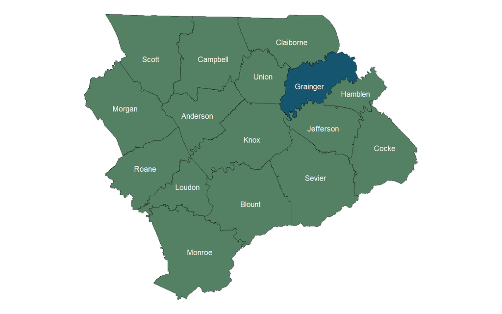

**Population and Growth**

| Place | 1970 | 1980 | 1990 | 2000 | 2010 | 2020 | Change 1970-1980 | Change 1980-1990 | Change 1990-2000 | Change 2000-2010 | Change 2010-2020 |
| --- | --- | --- | --- | --- | --- | --- | --- | --- | --- | --- | --- |
| Grainger County | 13948 | 16751 | 17095 | 20659 | 22657 | 23527 | 2803 | 344 | 3564 | 1998 | 870 |
| Bean Station |  |  |  |  | 2826 | 2967 |  |  |  |  | 141 |
| Blaine |  | 1147 | 1326 | 1585 | 1856 | 2084 |  | 179 | 259 | 271 | 228 |
| Rutledge |  | 1058 | 903 | 1187 | 1122 | 1321 |  | -155 | 284 | -65 | 199 |

[interactive chart not shown]

IPUMS NHGIS, University of Minnesota, www.nhgis.org

**Population Density**

| Place | Area | Population Density |
| --- | --- | --- |
| Grainger County | 302.3757038267051 | 77.80717730378095 |
| Bean Station | 5.990276276801951 | 495.3026977219826 |
| Blaine | 9.532421013990092 | 218.6223202837405 |
| Rutledge | 5.53543090282527 | 238.644474692253 |

[interactive chart not shown]

source: U. S. Census Bureau *Decennial Census: Redistricting Data (PL 94-171)*, 2020, accessed June 2, 2026, http://api.census.gov/data/2020/dec/pl.

**Population Descriptions**

| Place | Year | Race Category | Number of People | Percentage of People |
| --- | --- | --- | --- | --- |
| Grainger County | 2020 | Black | 124 | 0.004147295896183819 |
| Grainger County | 2020 | Other | 1469 | 0.04913207799591959 |
| Grainger County | 2020 | White | 21934 | 0.7336031305394829 |
| Bean Station | 2020 | Black | 15 | 0.0005016890196996555 |
| Bean Station | 2020 | Other | 164 | 0.005485133282049567 |
| Bean Station | 2020 | White | 2788 | 0.09324726579484263 |
| Blaine | 2020 | Black | 20 | 0.000668918692932874 |
| Blaine | 2020 | Other | 100 | 0.00334459346466437 |
| Blaine | 2020 | White | 1964 | 0.06568781564600823 |
| Rutledge | 2020 | Black | 12 | 0.0004013512157597244 |

[output cut: 2 more lines]

| Place | Sex | Age Range | Year | Number of People | Percentage of People |
| --- | --- | --- | --- | --- | --- |
| Grainger County | Female | 10 to 14 years | 2020 | 612 | 0.02052313883299799 |
| Grainger County | Female | 15 to 19 years | 2020 | 684 | 0.02293762575452716 |
| Grainger County | Female | 20 to 24 years | 2020 | 639 | 0.02142857142857143 |
| Grainger County | Female | 25 to 29 years | 2020 | 582 | 0.01951710261569416 |
| Grainger County | Female | 30 to 34 years | 2020 | 700 | 0.02347417840375587 |
| Grainger County | Female | 35 to 39 years | 2020 | 527 | 0.01767270288397049 |
| Grainger County | Female | 40 to 44 years | 2020 | 732 | 0.02454728370221328 |
| Grainger County | Female | 45 to 49 years | 2020 | 898 | 0.0301140174379611 |
| Grainger County | Female | 5 to 9 years | 2020 | 640 | 0.02146210596914822 |
| Grainger County | Female | 50 to 54 years | 2020 | 1000 | 0.0335345405767941 |

[output cut: 134 more lines]

[interactive chart not shown]

source: U. S. Census Bureau *Decennial Census: Redistricting Data (PL 94-171)*, 2020, accessed June 2, 2026, http://api.census.gov/data/2020/dec/pl.

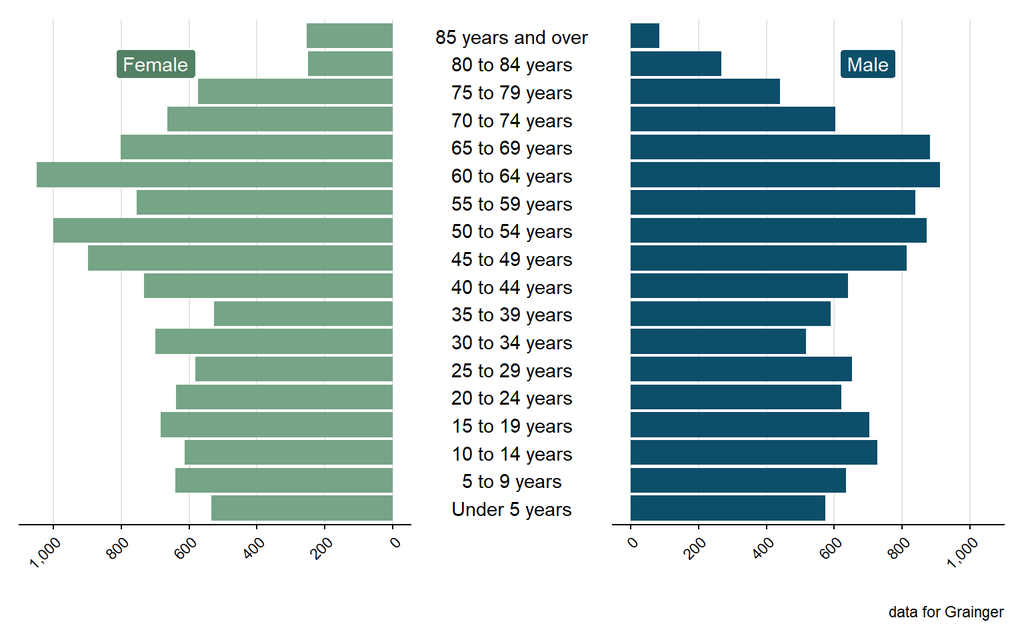

source: U. S. Census Bureau *American Community Survey 5-Year Estimates: Comparison Profiles 5-Year*, 2020, accessed June 2, 2026, http://api.census.gov/data/2020/acs/acs5.

**Education**

| Place | Level of Education | Year | Number of People | Percentage of People |
| --- | --- | --- | --- | --- |
| Grainger County | 9th to 12th Grade, No Diploma | 2010 | 2061 | 0.1003750060877612 |
| Grainger County | Associate's degree | 2010 | 810 | 0.03944869234890177 |
| Grainger County | Bachelor's degree | 2010 | 763 | 0.03715969415087907 |
| Grainger County | Graduate or Professional Degree | 2010 | 394 | 0.01918862319193494 |
| Grainger County | Less Than 9th Grade | 2010 | 2492 | 0.1213656065845225 |
| Grainger County | Some College, No Degree | 2010 | 2013 | 0.09803730580041883 |
| Grainger County | Total | 2010 | 15780 | 0.76851896946379 |
| Grainger County | 9th to 12th Grade, No Diploma | 2020 | 1640 | 0.0757121093208993 |
| Grainger County | Associate's degree | 2020 | 1192 | 0.05502977701860486 |
| Grainger County | Bachelor's degree | 2020 | 1413 | 0.06523244540879923 |

[output cut: 46 more lines]

[interactive chart not shown]

source: U. S. Census Bureau *American Community Survey 5-Year Estimates: Comparison Profiles 5-Year*, 2020, accessed June 2, 2026, http://api.census.gov/data/2020/acs/acs5.

**Housing Units by Year of Construction**

| Place | Year | 1939 or earlier | 1940-1959 | 1960-1979 | 1980 to 1989 | 1990 to 1999 | 2000 to 2004 | 2005 or later | 2000 to 2009 | 2010 or later | Total |
| --- | --- | --- | --- | --- | --- | --- | --- | --- | --- | --- | --- |
| Grainger County | 2010 | 899 | 1372 | 3018 | 1758 | 2598 | 871 | 254 |  |  | 10770 |
| Grainger County | 2020 | 798 | 1004 | 2299 | 1739 | 2787 |  |  | 1936 | 594 | 11157 |
| Bean Station | 2010 | 6 | 140 | 598 | 205 | 197 | 125 | 22 |  |  | 1293 |
| Blaine | 2010 | 20 | 120 | 224 | 169 | 222 | 86 | 30 |  |  | 871 |
| Rutledge | 2010 | 72 | 90 | 232 | 61 | 139 | 19 | 9 |  |  | 622 |
| Bean Station | 2020 | 71 | 163 | 421 | 234 | 287 |  |  | 167 | 0 | 1343 |
| Blaine | 2020 | 26 | 48 | 76 | 98 | 208 |  |  | 212 | 115 | 783 |
| Rutledge | 2020 | 62 | 114 | 169 | 111 | 171 |  |  | 43 | 29 | 699 |

[interactive chart not shown]

source: U. S. Census Bureau *Decennial Census: Redistricting Data (PL 94-171)*, 2020, accessed June 2, 2026, http://api.census.gov/data/2020/dec/pl.

**Housing Units by Type of Tenure**

| Place | Year | Own | Rent | Total |
| --- | --- | --- | --- | --- |
| Grainger County | 2010 | 7113 | 1510 | 8623 |
| Grainger County | 2020 | 6990 | 2157 | 9147 |
| Bean Station | 2010 | 882 | 267 | 1149 |
| Blaine | 2010 | 628 | 170 | 798 |
| Rutledge | 2010 | 278 | 235 | 513 |
| Bean Station | 2020 | 928 | 261 | 1189 |
| Blaine | 2020 | 501 | 234 | 735 |
| Rutledge | 2020 | 294 | 312 | 606 |

[interactive chart not shown]

source: U. S. Census Bureau *Decennial Census: Redistricting Data (PL 94-171)*, 2020, accessed June 2, 2026, http://api.census.gov/data/2020/dec/pl.

**Income Comparison**

| Place | Year | Median Family Income | Median Household Income | Per Capita Income |
| --- | --- | --- | --- | --- |
| Grainger County | 2020 | 54141 | 44703 | 23937 |
| Bean Station | 2020 | 65625 | 41723 | 25686 |
| Blaine | 2020 | 65972 | 54125 | 23288 |
| Rutledge | 2020 | 50000 | 30694 | 18566 |

[interactive chart not shown]

source: U. S. Census Bureau *Decennial Census: Redistricting Data (PL 94-171)*, 2020, accessed June 2, 2026, http://api.census.gov/data/2020/dec/pl.

**Povery Status**

| Place | Year | Above Poverty | Below Poverty |
| --- | --- | --- | --- |
| Grainger County | 2020 | 5650 | 808 |
| Bean Station | 2020 | 733 | 79 |
| Blaine | 2020 | 493 | 52 |
| Rutledge | 2020 | 281 | 25 |

[interactive chart not shown]

source: U. S. Census Bureau *American Community Survey 5-Year Estimates: Comparison Profiles 5-Year*, 2020, accessed June 2, 2026, http://api.census.gov/data/2020/acs/acs5.

**Poverty Status by Family Type**

| Place | Poverty Status | Family Type | Number of Families | Year | Percentage of Families |
| --- | --- | --- | --- | --- | --- |
| Grainger County | Above Poverty | All Families | 5650 | 2020 | 0.6957271272010837 |
| Grainger County | Above Poverty | Female Householder | 594 | 2020 | 0.0731437015145918 |
| Grainger County | Above Poverty | Female Householder with related children | 182 | 2020 | 0.02241103312399951 |
| Grainger County | Below Poverty | All Families | 808 | 2020 | 0.09949513606698683 |
| Grainger County | Below Poverty | Female Householder | 192 | 2020 | 0.02364240857037311 |
| Grainger County | Below Poverty | Female Householder with related children | 175 | 2020 | 0.02154907031153799 |
| Bean Station | Above Poverty | All Families | 733 | 2020 | 0.09025982021918483 |
| Bean Station | Above Poverty | Female Householder | 88 | 2020 | 0.01083610392808767 |
| Bean Station | Above Poverty | Female Householder with related children | 18 | 2020 | 0.002216475803472479 |
| Bean Station | Below Poverty | All Families | 79 | 2020 | 0.009727866026351435 |

[output cut: 14 more lines]

[interactive chart not shown]

source: U. S. Census Bureau *American Community Survey 5-Year Estimates: Comparison Profiles 5-Year*, 2020, accessed June 2, 2026, http://api.census.gov/data/2020/acs/acs5.

**Employment by Industry**

| Place | Industry | Year | Number of Jobs | Percentage of Jobs |
| --- | --- | --- | --- | --- |
| Bean Station | Construction | 2010 | 81 | 0.07848837209302326 |
| Bean Station | Construction | 2020 | 107 | 0.1236994219653179 |
| Bean Station | Educational Services, And Health Care And Social Assistance | 2010 | 141 | 0.1366279069767442 |
| Bean Station | Educational Services, And Health Care And Social Assistance | 2020 | 315 | 0.3641618497109826 |
| Bean Station | Manufacturing | 2010 | 294 | 0.2848837209302326 |
| Bean Station | Manufacturing | 2020 | 263 | 0.3040462427745665 |
| Bean Station | Other Industries | 2010 | 334 | 0.3236434108527132 |
| Bean Station | Other Industries | 2020 | 279 | 0.3225433526011561 |
| Bean Station | Retail Trade | 2010 | 146 | 0.1414728682170543 |
| Bean Station | Retail Trade | 2020 | 187 | 0.2161849710982659 |

[output cut: 38 more lines]

[interactive chart not shown]

source: U. S. Census Bureau *American Community Survey 5-Year Estimates: Comparison Profiles 5-Year*, 2020, accessed June 2, 2026, http://api.census.gov/data/2020/acs/acs5.

**Employment by Industry (Historical)**

| Place | Year | Industry | Number of Jobs | Percentage of Jobs |
| --- | --- | --- | --- | --- |
| Bean Station | 2010 | Agriculture, Forestry, Fishing And Hunting, And Mining | 17 | 0.001426294152193976 |
| Bean Station | 2010 | Construction | 81 | 0.006795872136924239 |
| Bean Station | 2010 | Manufacturing | 294 | 0.02466649886735464 |
| Bean Station | 2010 | Other | 65 | 0.005453477640741673 |
| Bean Station | 2010 | Professional Services | 275 | 0.02307240540313785 |
| Bean Station | 2010 | Public Administration | 47 | 0.003943283832536287 |
| Bean Station | 2010 | Trade, Finance, Insurance &amp; Real Estate | 253 | 0.02122661297088682 |
| Bean Station | 2020 | Agriculture, Forestry, Fishing And Hunting, And Mining | 0 | 0 |
| Bean Station | 2020 | Construction | 107 | 0.008479277280291624 |
| Bean Station | 2020 | Manufacturing | 263 | 0.02084158808146446 |

[output cut: 46 more lines]

**Labor Force by Place of Work**

| Place | Year | Work Out Of State | Work Out of County of Residence | Work in County of Residence |
| --- | --- | --- | --- | --- |
| Grainger County | 2020 | 341 | 6029 | 3204 |
| Bean Station | 2020 | 124 | 821 | 298 |
| Blaine | 2020 | 0 | 629 | 231 |
| Rutledge | 2020 | 0 | 302 | 220 |

[interactive chart not shown]

source: U. S. Census Bureau *American Community Survey 5-Year Estimates: Comparison Profiles 5-Year*, 2020, accessed June 2, 2026, http://api.census.gov/data/2020/acs/acs5.

**Commuting Patterns**

| Home County | Year | Number of Jobs | Percentage of Jobs |
| --- | --- | --- | --- |
| Grainger | 2010 | 1647 | 0.244907063197026 |
| Grainger | 2020 | 1567 | 0.2330111524163569 |
| Hamblen | 2020 | 392 | 0.05828996282527881 |
| Knox | 2020 | 287 | 0.04267657992565056 |
| Hamblen | 2010 | 241 | 0.0358364312267658 |
| Jefferson | 2020 | 216 | 0.03211895910780669 |
| Knox | 2010 | 182 | 0.02706319702602231 |
| Jefferson | 2010 | 108 | 0.01605947955390334 |
| Sevier | 2020 | 76 | 0.01130111524163569 |
| Sevier | 2010 | 19 | 0.002825278810408922 |

[output cut: 3 more lines]

| Work County | Year | Number of Jobs | Percentage of Jobs |
| --- | --- | --- | --- |
| Knox | 2020 | 2115 | 0.3144981412639405 |
| Knox | 2010 | 1868 | 0.2777695167286245 |
| Hamblen | 2020 | 1792 | 0.2664684014869889 |
| Grainger | 2010 | 1647 | 0.244907063197026 |
| Grainger | 2020 | 1567 | 0.2330111524163569 |
| Hamblen | 2010 | 1548 | 0.2301858736059479 |
| Hawkins | 2020 | 177 | 0.02631970260223048 |
| Claiborne | 2020 | 172 | 0.02557620817843866 |
| Hawkins | 2010 | 158 | 0.02349442379182156 |
| Claiborne | 2010 | 122 | 0.01814126394052045 |

[output cut: 3 more lines]

[interactive chart not shown]

source: U. S. Census Bureau *Tn_od_main_JT00_2020*, LEHD Origin-Destination Employment Statistics, 8.3, 2020, accessed June 2, 2026, https://lehd.ces.census.gov/data/lodes/.

## References

Bureau, U. S. Census. *American Community Survey 5-Year Estimates: Comparison Profiles 5-Year*. 2020. Accessed June 2, 2026. http://api.census.gov/data/2020/acs/acs5.

Bureau, U. S. Census. *Decennial Census: Redistricting Data (PL 94-171)*. 2020. Accessed June 2, 2026. http://api.census.gov/data/2020/dec/pl.

Bureau, U. S. Census. *Tn_od_main_JT00_2020*. LEHD Origin-Destination Employment Statistics, 8.3. 2020. Accessed June 2, 2026. https://lehd.ces.census.gov/data/lodes/.